# Practical Machine Learning - Course Project

## *Eric Pao*

The goal of the project is to analyze *personal activity data* for 6 participants and build a model to predict the manner in which they did the exercise. The data is from accelerometers worn on the belt, forearm, arm, and dumbbell for the 6 participants. They were asked to perform barbell lifts correctly and incorrectly in 5 different ways:

A. Exact/Correct Movement  
B. Throwing Elbows to the Front  
C. Lifting the Dumbbell Only Halfway  
D. Lowering the Dumbbell Only Halfway  
E. Throwing the Hips to the Front

### Data Loading

The first step would be to load the data. The data was already split into training and test sets that we can load as data frames into R.

```r
# Load Training Data
if(!exists("pml_training)")) {
  pml_training <- read.csv("pml-training.csv",header=TRUE,na.strings=c("","NA"),row.names=1)
}

# Load Testing Data
if(!exists("pml_testing")) {
  pml_testing <- read.csv("pml-testing.csv",header=TRUE,na.strings=c("","NA"),row.names=1)
}
```

For a simple QC, we should ensure the structure of both files are the same. Specifically, we check whether the column names are the same between both data sets. As shown below, we see that the test and training data sets contain the same features (with the exception of the training set including a variable for “classe” and the test set including the problem ID).

```r
# QC to make sure column names are same
training_names <- names(pml_training)
testing_names <- names(pml_testing)

# Which column names are different
training_names[which(training_names != testing_names)]
```

```
## [1] "classe"
```

```r
testing_names[which(training_names != testing_names)]
```

```
## [1] "problem_id"
```

### Data Preprocessing

In this section, we want to prep the data for modeling by removing erroneous features from the data, especially since we currently have **158 possible predictors** in the data. If we look at the list of features, we notice there are a few that will most likely *not* play a role in predicting the class of activity, namely the **timestamp** and **new window** variables.

The code below removes the irrelevant features (i.e. timestamp, window) and the features with majority missing values. This will cull down the number of available features for us to consider when modeling and reduce complexity significantly. What we’re left with is a dataset with 53 features that we model in the next section.

```r
# Timestamp, window shouldn't impact prediction
invalid <- grepl("timestamp|window",training_names)
clean_training <- pml_training[,!invalid]
clean_testing <- pml_testing[,!invalid]

# Check for columns with nas #
colNAs <- colSums(is.na(clean_training))
#unique(colNAs)
#sum(colNAs>0)
#unique(colNAs/nrow(pml_training))

# Identify column names in training dataset with NA values
na_names <- names(colNAs[colNAs!=0])

# Drop relevant columns in test and training set
clean_training <- clean_training[,!(names(clean_training) %in% na_names)]
clean_testing <- clean_testing[,!(names(clean_testing) %in% na_names)]
```

### Data Modeling

Among the options of classification models, **Random Forests** provide the benefits of bagged decision trees (i.e. reducing variance of single trees) while decorrelating the trees by minimizing the number of predictors available at each split. By default, Random Forests only allow for a subset of $m=\sqrt{p}$ predictors to be chosen at each split. This leads to a reduction in bias and OOB error.

Using a Random Forest routine also **eliminates the need for an explicit cross-validation step**. This is because the bagged trees area already fit repeatedly to bootstrapped subsets of the given observations. On average, approximately **2/3rds** of the observations are used in each bagged tree.

We can use the **RandomForest** library to fit a random forest model using the preprocessed training data from the previous step.

```r
set.seed(12345)
library(randomForest)
rf.activity <- randomForest(classe~.,data=clean_training,importance=TRUE)
```

As you can see below, we grew a large number of 500 trees and limited the number of variables at each split to be 7. The Random Forest routine compared the predictor with the set of observations not used in generating the bagged trees (i.e. Out-of-Bag Observations).

In looking at the results, the model fit seems fairly accurrate, with an **OOB error rate of 0.29%**.

```
##
## Call:
##  randomForest(formula = classe ~ ., data = clean_training, importance = TRUE)
##                Type of random forest: classification
##                      Number of trees: 500
## No. of variables tried at each split: 7
##
##         OOB estimate of  error rate: 0.29%
## Confusion matrix:
##      A    B    C    D    E  class.error
## A 5578    1    0    0    1 0.0003584229
## B    7 3787    3    0    0 0.0026336582
## C    0   12 3408    2    0 0.0040911748
## D    0    0   23 3191    2 0.0077736318
## E    0    0    0    5 3602 0.0013861935
```

We can also take a look at the **Variable Importance Measures** to interpret our model. As you can see below, the **roll_belt** feature has the largest mean decrease in Gini Index. In other words, removing roll_belt would drastically increase the node impurity, making it the most important variable across all the bagged trees in our random forest.

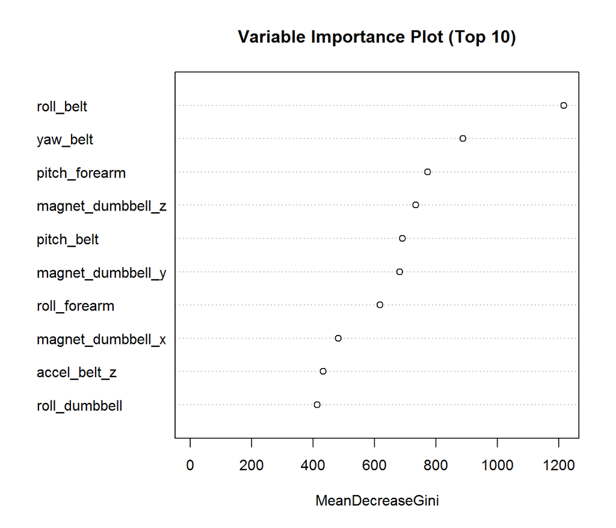

### Predicting our Test Cases

We’ll now want to complete the assignment by predicting the classes for our test data set.

```r
pred.activity <- predict(rf.activity,clean_testing,type="class")
pred.activity
```

```
##  1  2  3  4  5  6  7  8  9 10 11 12 13 14 15 16 17 18 19 20
##  B  A  B  A  A  E  D  B  A  A  B  C  B  A  E  E  A  B  B  B
## Levels: A B C D E
```

### Data Source

Velloso, E.; Bulling, A.; Gellersen, H.; Ugulino, W.; Fuks, H. Qualitative Activity Recognition of Weight Lifting Exercises. Proceedings of 4th International Conference in Cooperation with SIGCHI (Augmented Human ’13) . Stuttgart, Germany: ACM SIGCHI, 2013.